# heidi

**Institution Profile**

**Classification:** Professions-focused Undergraduate/Graduate-Doctorate Small

**Size:** Small

**Award Level Focus:** Undergraduate/Graduate-Doctorate

**UG Program Mix:** Professions-focused

**Grad Program Mix:** Special Focus: Other Health Professions

**Research Activity:** No research designation

**Student Access & Earnings:** Higher Access, Medium Earnings

**Top Degree Programs — 2023-24**

| Program | % of Degrees |
| --- | --- |
| Business Administration, Management and Operations. | 20.0% |
| Rehabilitation and Therapeutic Professions. | 12.3% |
| Registered Nursing, Nursing Administration, Nursing Research and Clinical Nursing. | 12.3% |

**Location**

[interactive chart not shown]

#### Higher Education Institutional Data Interface (HEIDI)

HEIDI is a dashboard tool created by the Casagrande Institute to report data for institutions of higher education.

#### Casagrande Institute

The [Casagrande Institute](https://www.viterbo.edu/casagrande-institute/) helps institutions develop effective compensation practices for executives, faculty, and staff.

**Group Overview**

- **AUTO**: Created by IPEDS in 2024-25 based on an internal grouping process involving Level, Control, Carnegie classification, and other variables.
- **CUSTOM**: The group of comparison institutions submitted to IPEDS by Clarke in 2024-25.
- **REVERSE**: The group of institutions that included Clarke in their 2024-25 IPEDS custom group.

**Group Membership**

| Institution | AUTO | CUSTOM | REVERSE |
| --- | --- | --- | --- |
| AIB College of Business |  |  | ✓ |
| Albizu University-Miami | ✓ |  |  |
| American International College | ✓ |  |  |
| Aurora University |  | ✓ |  |
| Avila University |  |  | ✓ |
| Baker University | ✓ |  |  |
| Bastyr University | ✓ |  |  |
| Beloit College |  | ✓ |  |
| Benedictine University |  | ✓ |  |
| Bethany College |  |  | ✓ |

[output cut: 57 more lines]

**AUTO**

[interactive table not shown]

**CUSTOM**

[interactive table not shown]

**REVERSE**

[interactive table not shown]

**AUTO**

**Financial and Student Positioning of Clarke Within the AUTO Group**

| Metric | **AUTO Group** n | **AUTO Group** Min | **AUTO Group** p25 | **AUTO Group** Median | **AUTO Group** p75 | **AUTO Group** Max | **Spread** Spread | **Clarke** Clarke | **Clarke** Percentile | **Clarke** % of Median |
| --- | --- | --- | --- | --- | --- | --- | --- | --- | --- | --- |
| Revenue | 32 | 13.1M | 27.2M | 43.7M | 54.4M | 223.0M |  | 36.0M | 42 | 82% |
| Expenses | 32 | 13.6M | 29.9M | 43.1M | 52.8M | 199.5M |  | 29.8M | 27 | 69% |
| Margin | 32 | −8.0M | −2.1M | 1.2M | 4.0M | 23.6M |  | 6.1M | 83 | 512% |
| Endowment | 30 | 762.3k | 12.4M | 36.4M | 64.4M | 235.1M |  | 32.7M | 45 | 90% |
| Avg Net Price | 26 | 2.8k | 17.3k | 23.2k | 26.7k | 37.9k |  | 26.7k | 75 | 115% |
| Avg Net Price + 0.04 * Endowment / UG FTE | 25 | 11.2k | 19.6k | 25.5k | 28.3k | 39.2k |  | 28.5k | 78 | 112% |
| 12-Month Unduplicated Headcount | 32 | 780 | 1,302 | 2,353 | 2,612 | 4,118 |  | 1,076 | 8 | 46% |
| Undergrad FTE | 30 | 27 | 585 | 1,068 | 1,265 | 1,698 |  | 753 | 32 | 71% |
| Grad FTE | 32 | 72 | 294 | 464 | 578 | 1,237 |  | 51 | 2 | 11% |
| Doc Prof Prac FTE | 23 | 0 | 40 | 170 | 311 | 817 |  | 86 | 33 | 51% |
| Total FTE | 32 | 450 | 883 | 1,602 | 1,898 | 2,344 |  | 890 | 30 | 56% |
| Student-to-Faculty Ratio | 29 | 3.0 | 10.0 | 12.0 | 14.0 | 16.0 |  | 9.0 | 16 | 75% |
| Undergrad Pell % | 30 | 0 | 25 | 38 | 47 | 89 |  | 37 | 48 | 96% |
| Program Breadth (distinct 4-digit CIPs) | 32 | 5 | 18 | 26 | 33 | 43 |  | 19 | 31 | 75% |
| Top 5 Programs % of Completions | 32 | 46 | 60 | 71 | 80 | 100 |  | 64 | 34 | 90% |
| Distinct Award Levels Offered | 32 | 3 | 4 | 4 | 6 | 8 |  | 4 | 41 | 100% |

Data from IPEDS for the 2024-25 academic year. Group values exclude data from Clarke.

**CUSTOM**

**Financial and Student Positioning of Clarke Within the CUSTOM Group**

| Metric | **CUSTOM Group** n | **CUSTOM Group** Min | **CUSTOM Group** p25 | **CUSTOM Group** Median | **CUSTOM Group** p75 | **CUSTOM Group** Max | **Spread** Spread | **Clarke** Clarke | **Clarke** Percentile | **Clarke** % of Median |
| --- | --- | --- | --- | --- | --- | --- | --- | --- | --- | --- |
| Revenue | 24 | 27.7M | 44.1M | 65.5M | 104.4M | 778.1M |  | 36.0M | 10 | 55% |
| Expenses | 24 | 26.4M | 45.1M | 58.8M | 91.7M | 675.9M |  | 29.8M | 6 | 51% |
| Margin | 24 | −10.1M | −595.6k | 5.4M | 25.2M | 102.2M |  | 6.1M | 56 | 114% |
| Endowment | 24 | 23.1M | 55.6M | 96.4M | 215.3M | 1.1B |  | 32.7M | 6 | 34% |
| Avg Net Price | 24 | 18.0k | 22.9k | 24.2k | 26.3k | 39.1k |  | 26.7k | 77 | 110% |
| Avg Net Price + 0.04 * Endowment / UG FTE | 24 | 18.7k | 24.0k | 27.6k | 30.2k | 42.6k |  | 28.5k | 60 | 103% |
| 12-Month Unduplicated Headcount | 24 | 1,080 | 1,328 | 2,202 | 4,226 | 19,223 |  | 1,076 | 2 | 49% |
| Undergrad FTE | 24 | 628 | 1,134 | 1,439 | 2,548 | 12,173 |  | 753 | 6 | 52% |
| Grad FTE | 20 | 2 | 73 | 424 | 833 | 2,655 |  | 51 | 22 | 12% |
| Doc Prof Prac FTE | 12 | 9 | 75 | 130 | 378 | 1,553 |  | 86 | 29 | 66% |
| Total FTE | 24 | 793 | 1,279 | 1,786 | 3,356 | 15,966 |  | 890 | 6 | 50% |
| Student-to-Faculty Ratio | 24 | 9.0 | 11.0 | 12.0 | 14.0 | 18.0 |  | 9.0 | 4 | 75% |
| Undergrad Pell % | 24 | 15 | 23 | 28 | 35 | 53 |  | 37 | 81 | 130% |
| Program Breadth (distinct 4-digit CIPs) | 24 | 23 | 33 | 36 | 46 | 104 |  | 19 | 2 | 53% |
| Top 5 Programs % of Completions | 24 | 32 | 40 | 45 | 58 | 75 |  | 64 | 90 | 142% |
| Distinct Award Levels Offered | 24 | 1 | 2 | 4 | 5 | 9 |  | 4 | 54 | 100% |

Data from IPEDS for the 2024-25 academic year. Group values exclude data from Clarke.

**REVERSE**

**Financial and Student Positioning of Clarke Within the REVERSE Group**

| Metric | **REVERSE Group** n | **REVERSE Group** Min | **REVERSE Group** p25 | **REVERSE Group** Median | **REVERSE Group** p75 | **REVERSE Group** Max | **Spread** Spread | **Clarke** Clarke | **Clarke** Percentile | **Clarke** % of Median |
| --- | --- | --- | --- | --- | --- | --- | --- | --- | --- | --- |
| Revenue | 16 | 18.7M | 28.2M | 35.6M | 42.7M | 117.6M |  | 36.0M | 53 | 101% |
| Expenses | 16 | 17.8M | 31.3M | 37.2M | 41.1M | 66.0M |  | 29.8M | 28 | 80% |
| Margin | 16 | −8.2M | −1.4M | −773.8k | 1.3M | 51.6M |  | 6.1M | 84 | NA |
| Endowment | 16 | 4.6M | 17.0M | 34.5M | 51.1M | 281.6M |  | 32.7M | 53 | 95% |
| Avg Net Price | 16 | 17.0k | 21.1k | 23.6k | 24.7k | 28.2k |  | 26.7k | 97 | 113% |
| Avg Net Price + 0.04 * Endowment / UG FTE | 16 | 17.4k | 23.7k | 24.7k | 26.2k | 34.7k |  | 28.5k | 84 | 115% |
| 12-Month Unduplicated Headcount | 16 | 689 | 1,294 | 1,765 | 2,475 | 3,611 |  | 1,076 | 9 | 61% |
| Undergrad FTE | 16 | 573 | 849 | 1,051 | 1,223 | 1,412 |  | 753 | 28 | 72% |
| Grad FTE | 15 | 40 | 91 | 235 | 422 | 580 |  | 51 | 10 | 22% |
| Doc Prof Prac FTE | 3 | 17 | 55 | 93 | 120 | 147 |  | 86 | 50 | 92% |
| Total FTE | 16 | 573 | 1,030 | 1,258 | 1,586 | 1,974 |  | 890 | 22 | 71% |
| Student-to-Faculty Ratio | 16 | 10.0 | 12.0 | 12.0 | 13.0 | 19.0 |  | 9.0 | 3 | 75% |
| Undergrad Pell % | 16 | 10 | 26 | 38 | 46 | 56 |  | 37 | 50 | 96% |
| Program Breadth (distinct 4-digit CIPs) | 16 | 20 | 27 | 30 | 36 | 44 |  | 19 | 3 | 63% |
| Top 5 Programs % of Completions | 16 | 40 | 49 | 58 | 63 | 79 |  | 64 | 78 | 111% |
| Distinct Award Levels Offered | 16 | 1 | 2 | 3 | 5 | 6 |  | 4 | 66 | 133% |

Data from IPEDS for the 2024-25 academic year. Group values exclude data from Clarke.  
% of Median is suppressed where the group median is negative or where signs differ, as the ratio is not meaningful.

**AUTO**

**Revenue**

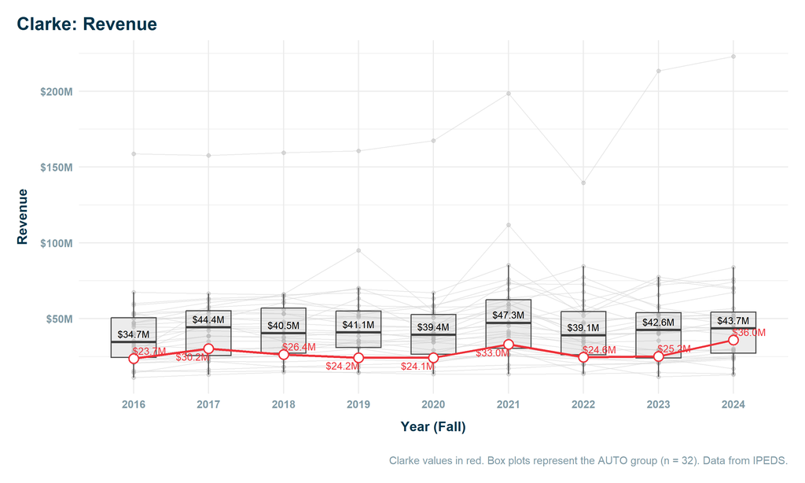

**Expenses**

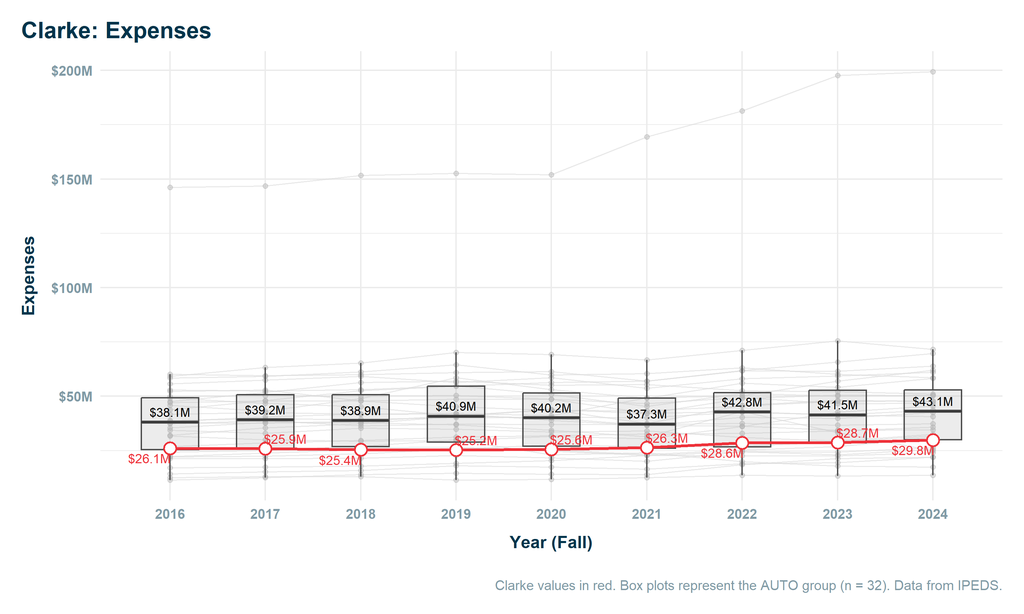

**Margin**

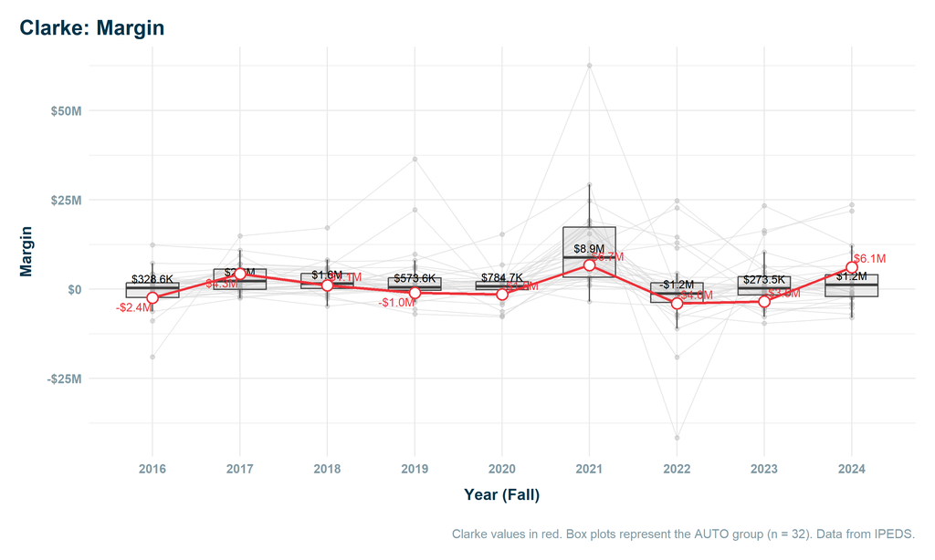

**Endowment**

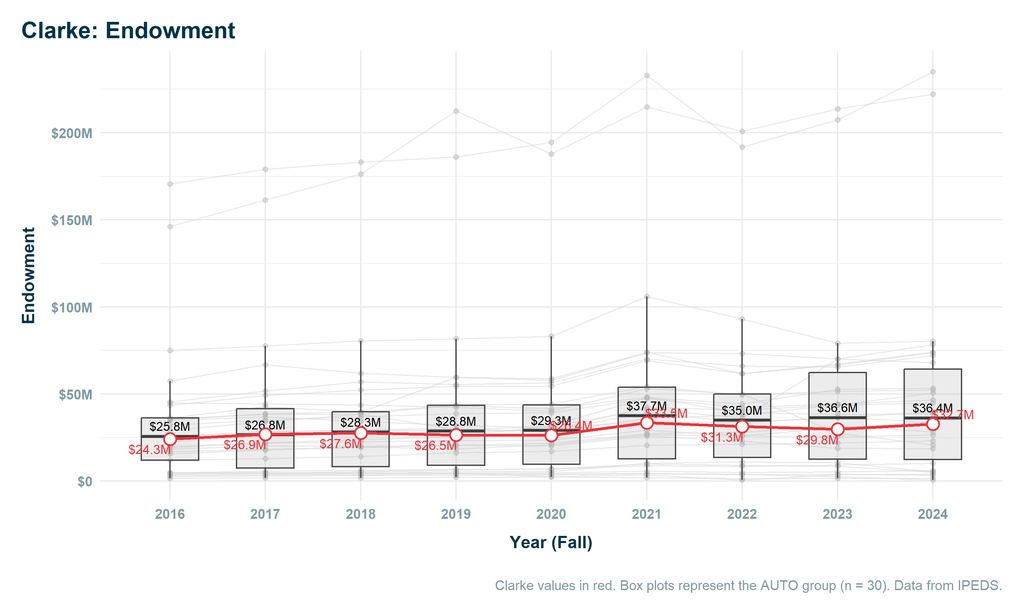

**Avg Net Price**

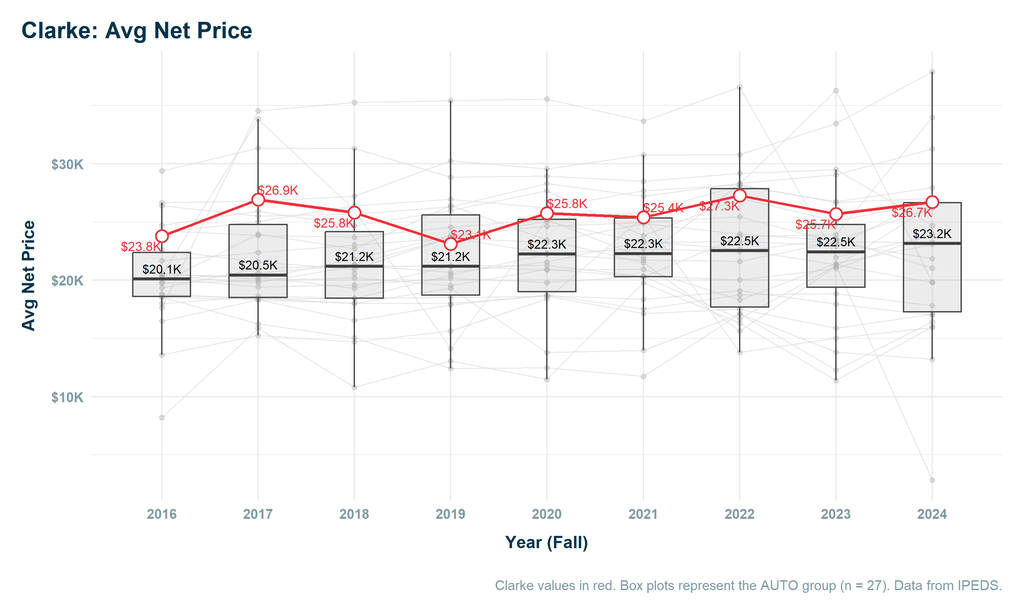

**Avg Net Price + 0.04 * Endowment / UG FTE**

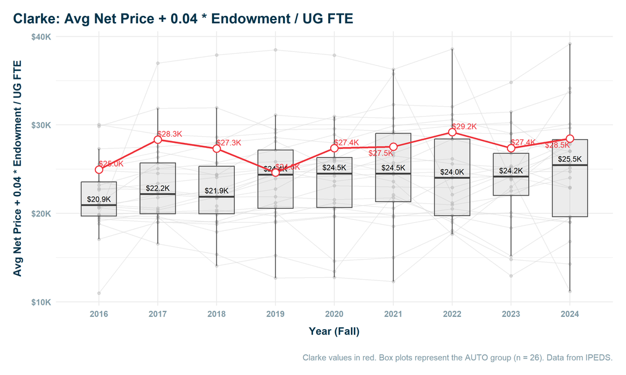

**12-Month Unduplicated Headcount**

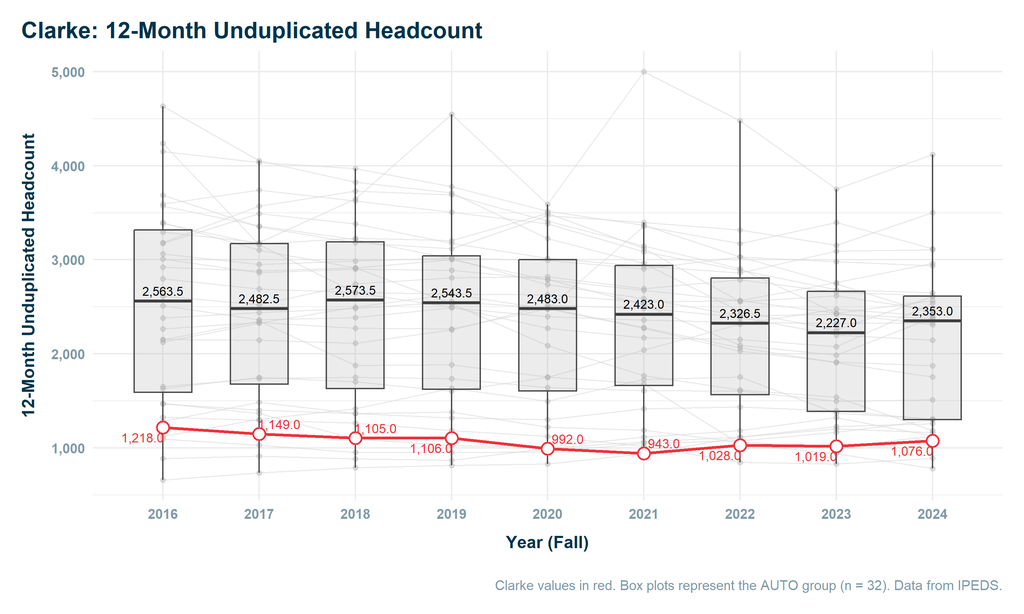

**Undergrad FTE**

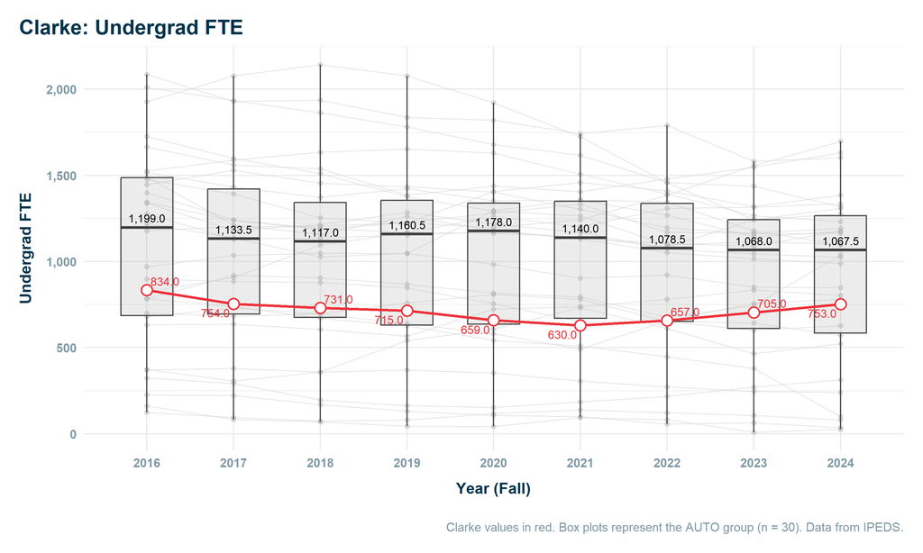

**Grad FTE**

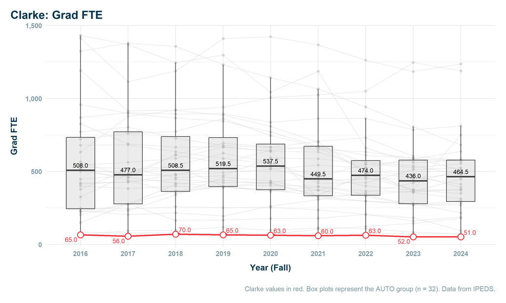

**Doc Prof Prac FTE**

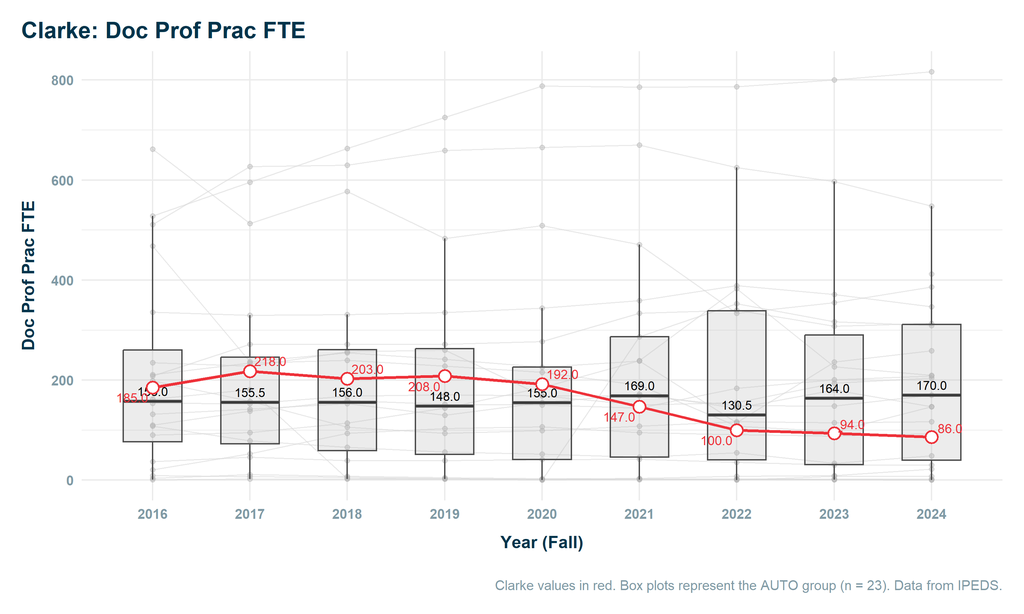

**Total FTE**

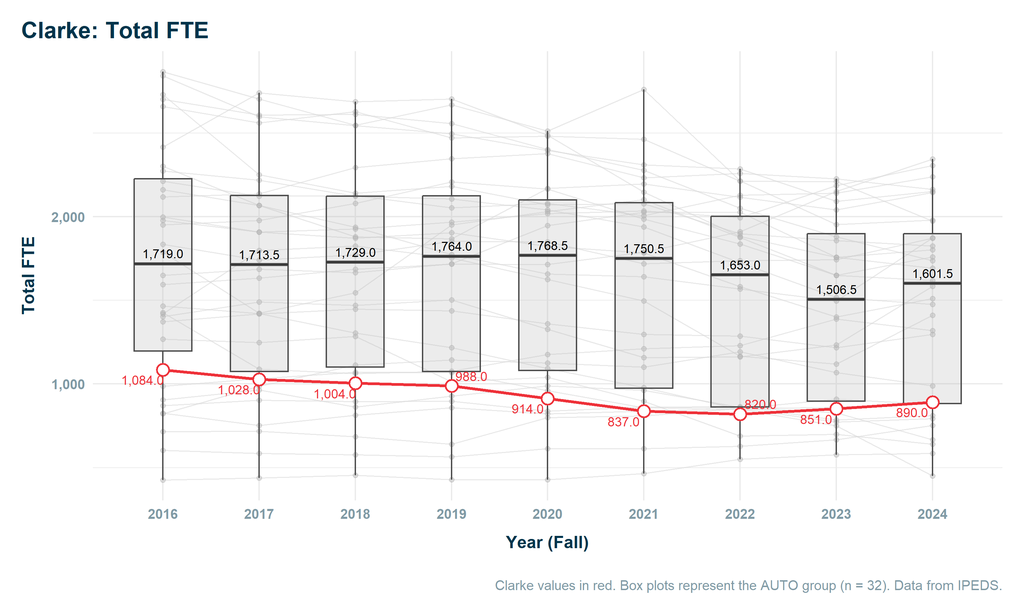

**Student-to-Faculty Ratio**

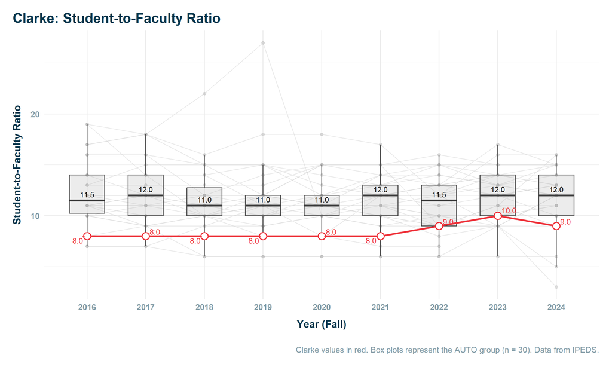

**Undergrad Pell %**

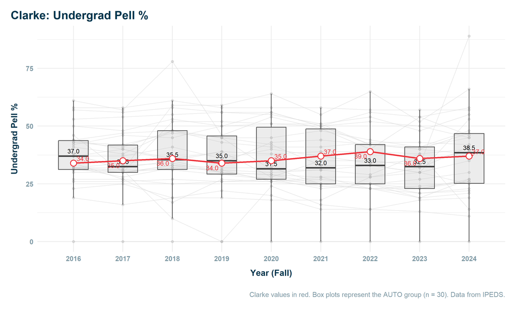

**Program Breadth (distinct 4-digit CIPs)**

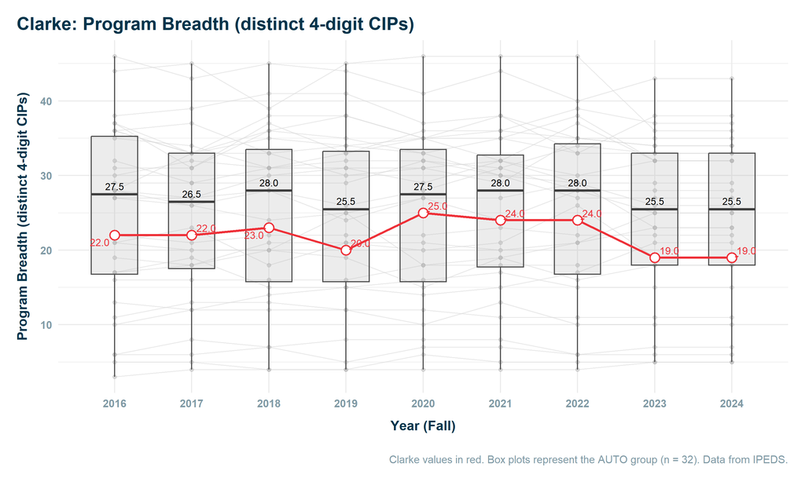

**Top 5 Programs % of Completions**

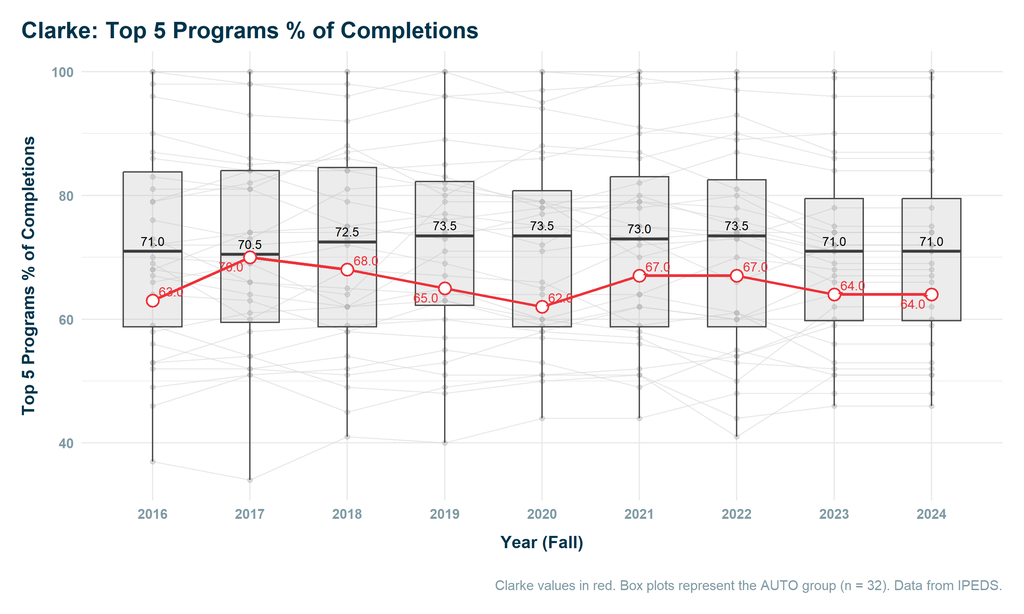

**Distinct Award Levels Offered**

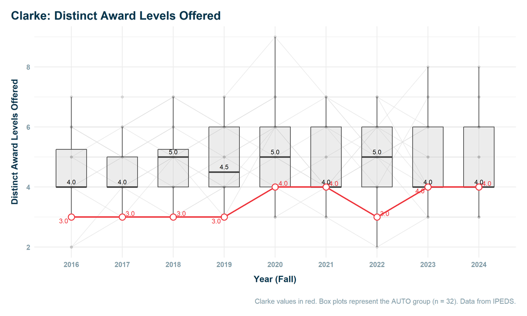

**CUSTOM**

**Revenue**

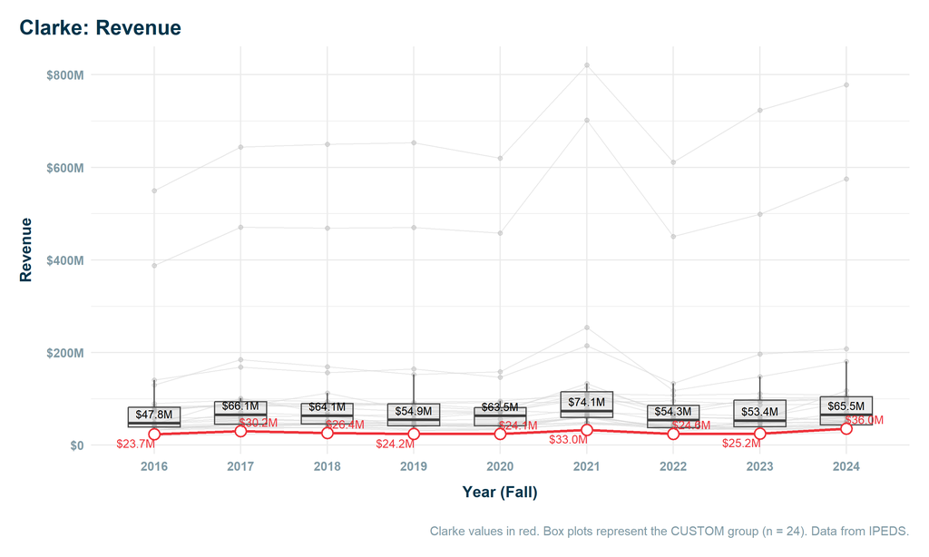

**Expenses**

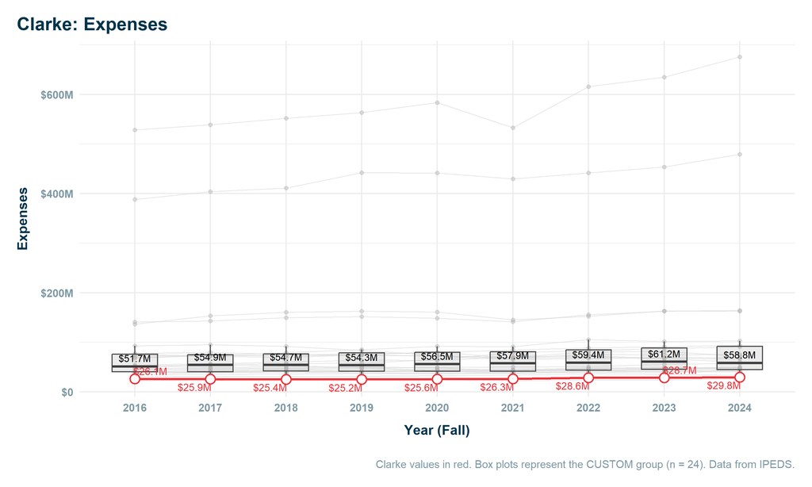

**Margin**

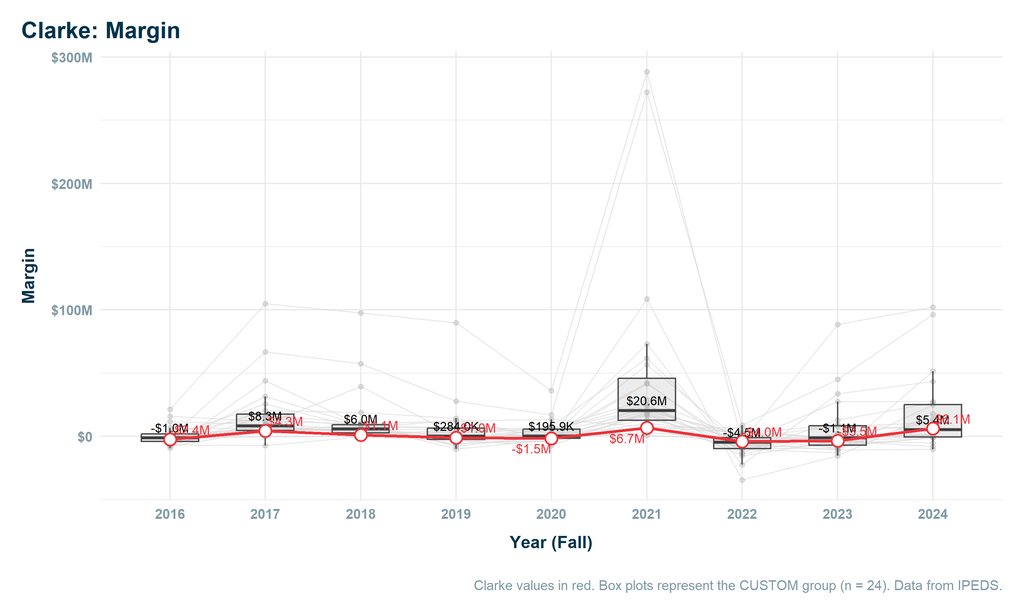

**Endowment**

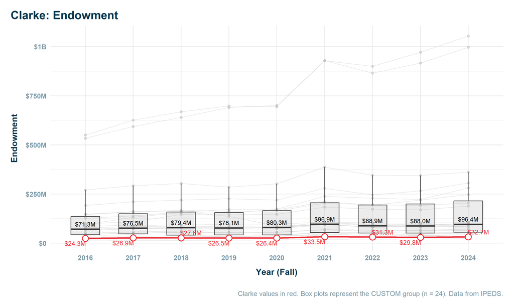

**Avg Net Price**

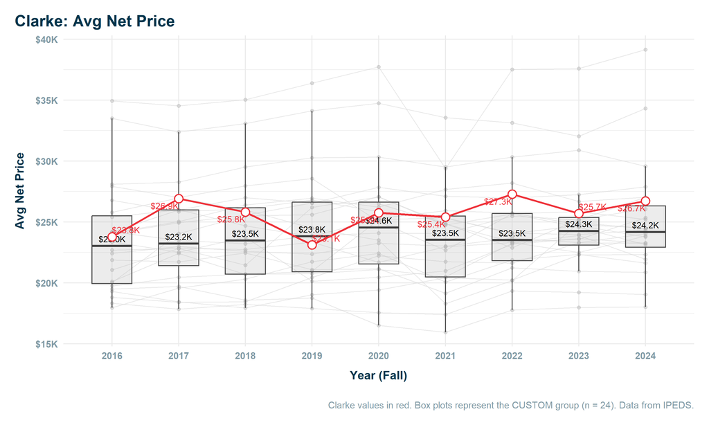

**Avg Net Price + 0.04 * Endowment / UG FTE**

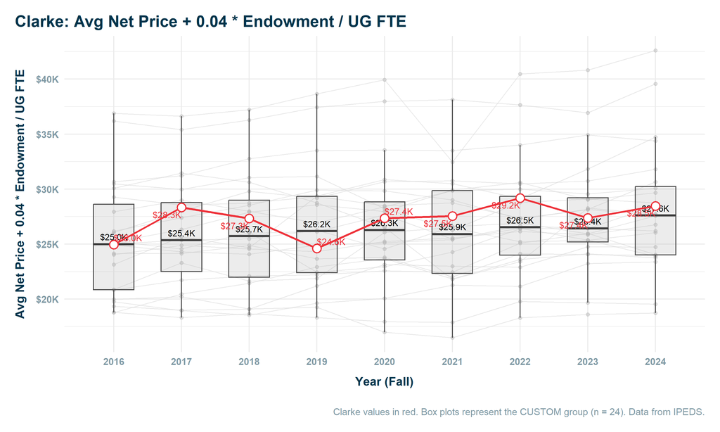

**12-Month Unduplicated Headcount**

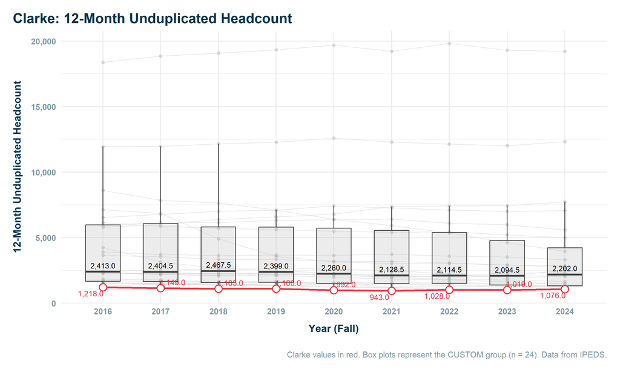

**Undergrad FTE**

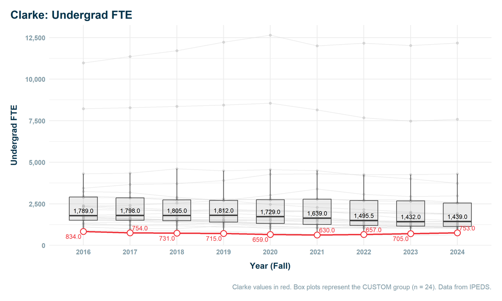

**Grad FTE**

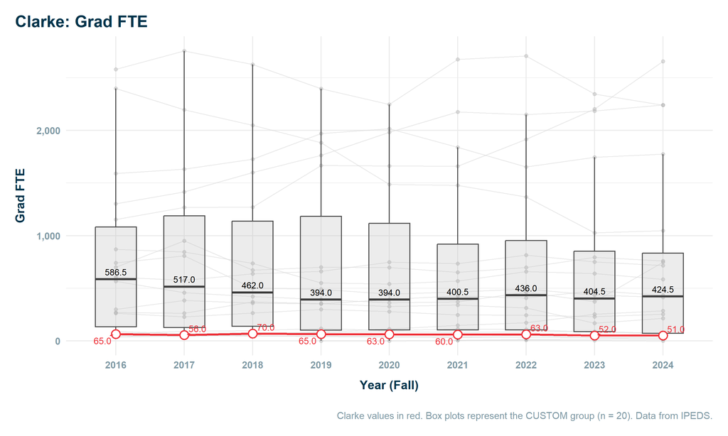

**Doc Prof Prac FTE**

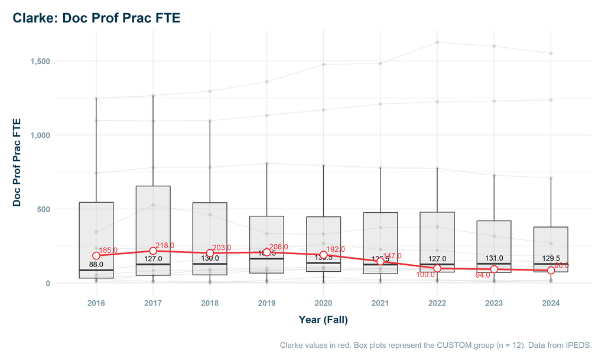

**Total FTE**

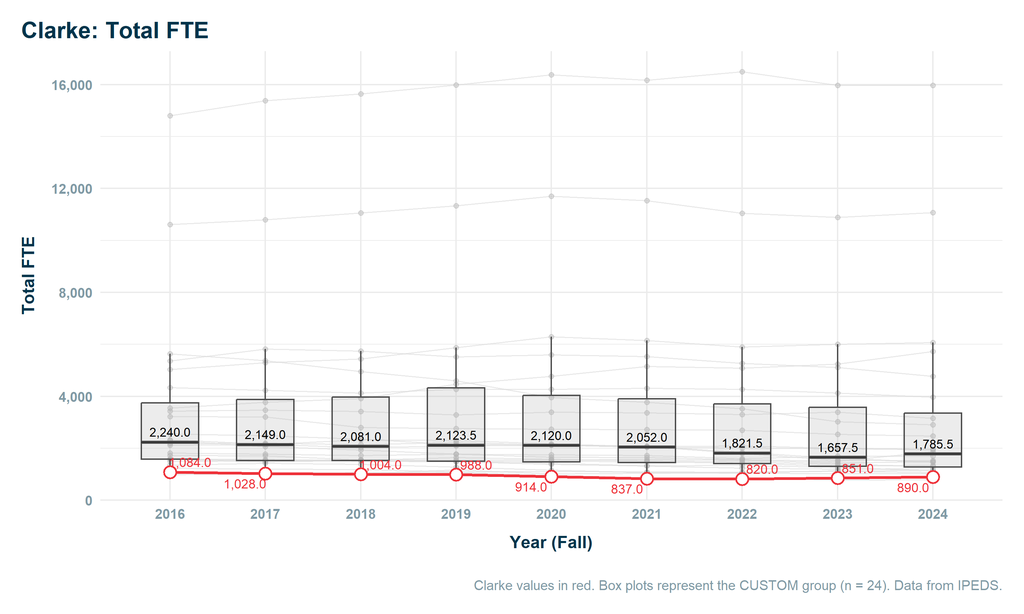

**Student-to-Faculty Ratio**

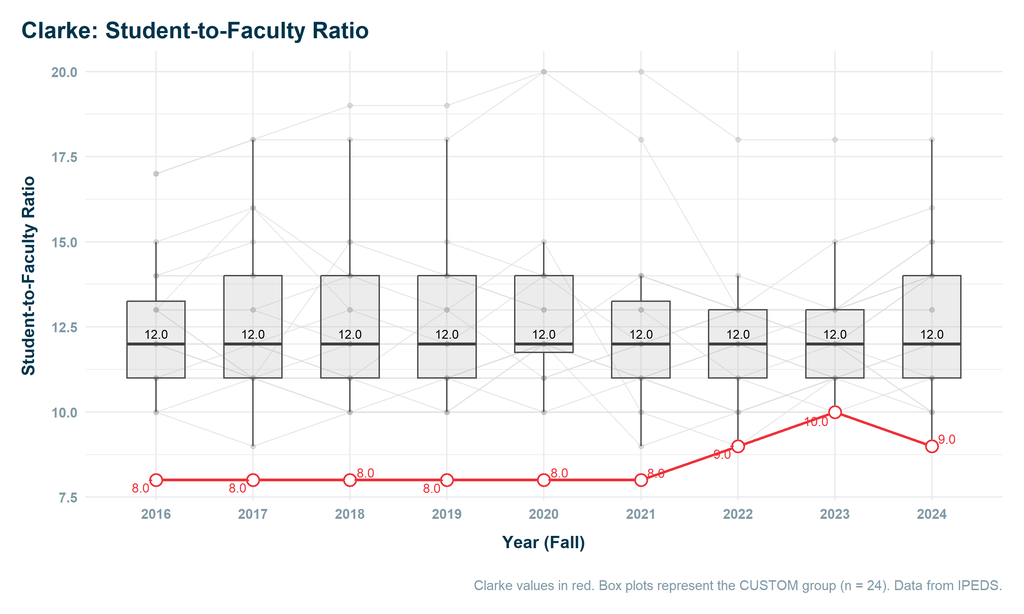